# Is There Gender Bias In Philosophical Texts?

Dipesh Patel

10/6/2021

This project was conducted with these R environmental settings.

```r
print(R.version)
```

```
##                _
## platform       x86_64-apple-darwin17.0
## arch           x86_64
## os             darwin17.0
## system         x86_64, darwin17.0
## status
## major          4
## minor          0.3
## year           2020
## month          10
## day            10
## svn rev        79318
## language       R
## version.string R version 4.0.3 (2020-10-10)
## nickname       Bunny-Wunnies Freak Out
```

```r
packages.used = c("tidyverse", "tidytext")
packages.needed = setdiff(packages.used, intersect(installed.packages()[, 1], packages.used))

if (length(packages.needed) > 0) {
  install.packages(packages.needed, dependencies = TRUE)
}

# load packages
library(tidyverse)
library(tidytext)
```

We are interested in how pronouns have been used throughout the history of philosophy. We have a collection of historical texts that we will analyze for this purpose. Each text is organized in one sentence per row format. In order to facilitate efficient analysis we change the structure of the data into one word per row format.

```r
# load the data
raw_data <- read_csv("../data/philosophy_data.csv")

# remove unnecessary variables and add sentence number for each title
tokenized <- raw_data %>%
  dplyr::select(-4, -5, -7, -9, -11) %>%
  group_by(title) %>%
  mutate(sentence = row_number()) %>%
  ungroup()

# put into tidy format with one word per row
tokenized_tidy <- tokenized %>%
  unnest_tokens(word, tokenized_txt)
```

We include all but indefinite pronouns to simplify analysis since there are very many of these kinds of pronouns.

```r
# list of pronouns
personal_pronouns <- c("i", "we", "you", "he", "she", "it", "they")
object_pronouns <- c("me", "us", "you", "her", "him", "it", "them")
possessive_pronouns <- c("mine", "ours", "yours", "hers", "his", "theirs")
possessive_adjectives <- c("my", "our", "your", "her", "his", "their")
reflexive_pronouns <- c("myself", "yourself", "herself", "himself", "itself", "ourselves",
                        "yourselves", "themselves")
archaic_pronouns <- c("thou", "thee", "thy", "thine", "ye")

pronouns <- c(personal_pronouns, object_pronouns, possessive_pronouns,
              possessive_adjectives, reflexive_pronouns, archaic_pronouns)
```

We can clearly see that “it” is the most commonly used pronoun. However, it is interesting to note how much more frequently versions of the “he” pronoun are used in comparison to “she”. We inspect this further.

```r
# count pronouns
pronouns_df <- tokenized_tidy %>%
  filter(word %in% pronouns) %>%
  count(word) %>%
  arrange(desc(n))

pronouns_df
```

```
## # A tibble: 34 x 2
##    word        n
##    <chr>   <int>
##  1 it     153145
##  2 we      60538
##  3 they    45628
##  4 he      39492
##  5 their   33295
##  6 them    28125
##  7 his     27010
##  8 itself  23896
##  9 our     20647
## 10 you     19642
## # … with 24 more rows
```

The barchart confirms that “he” pronouns are used much more frequently than “she” pronouns. There is a bias that is present towards more male associated pronouns in these philosophical texts.

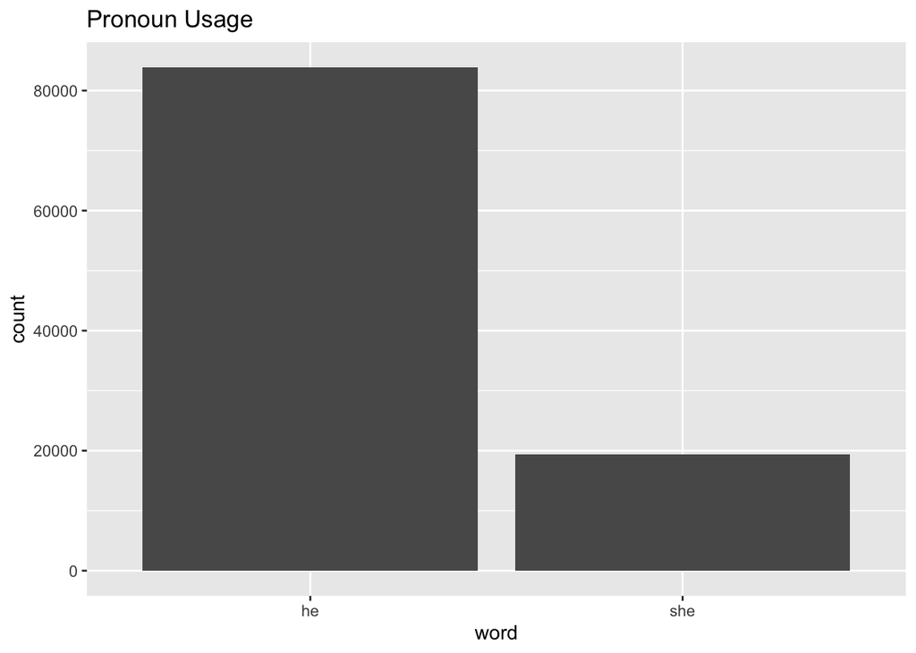

```r
# convert all "he"/"she" pronoun variations to "he"/"she" respectively
heshe_df <- tokenized_tidy %>%
  mutate(word = ifelse(word %in% c("he", "him", "his", "himself"), "he", word)) %>%
  mutate(word = ifelse(word %in% c("she", "her", "hers", "herself"), "she", word))

# create barchart of count
ggplot(heshe_df %>% filter(word %in% c("he", "she"))) +
  geom_bar(mapping = aes(x = word)) +
  labs(title = "Pronoun Usage")
```

Inspecting further, we see that almost all the authors use each pronoun similar save for several of them such as Beauvoir, Davis, and Wollstonecraft. More resolution will be provided comparing the ratios of he and she usage.

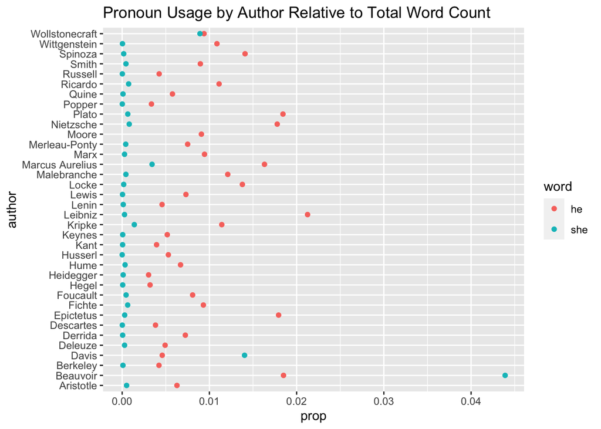

```r
author_school_df <- heshe_df %>%
  group_by(school, author, word) %>%
  summarise(count = n()) %>%
  mutate(prop = count / sum(count)) %>%
  ungroup() %>%
  filter(word %in% c("he", "she"))

ggplot(author_school_df) +
  geom_point(aes(x = prop, y = author, color = word)) +
  labs(title = "Pronoun Usage by Author Relative to Total Word Count")
```

The dotplot reveals that the only two authors who mention she pronouns more frequently than he pronouns are Beauvoir and Davis. Wollstonecraft is about even. However these three authors are not surprising since they belong to the feminism school.

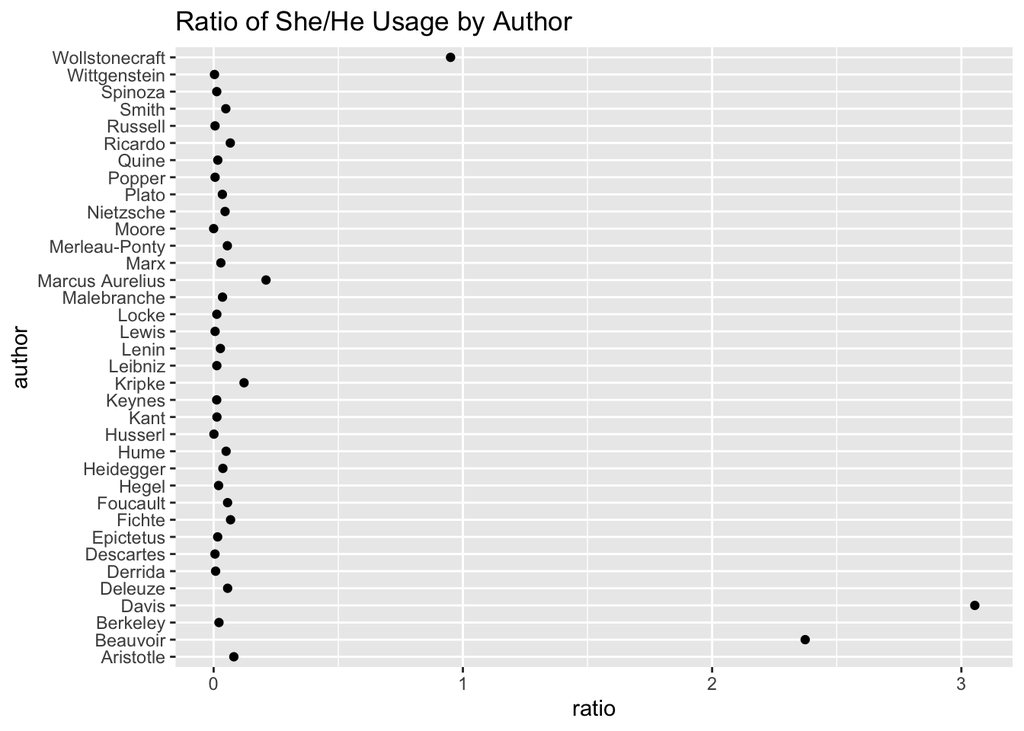

```r
# dot plot of ratio of "she"/"he" usage compared to overall by author
# edge point symbolizes infinity
author_school_df %>%
  group_by(author, word) %>%
  summarise(count = sum(count)) %>%
  ungroup() %>%
  add_row(author = "Moore", word = "she", count = 0, .after = 51) %>%
  group_by(author) %>%
  summarise(ratio_shehe = count[[2]]/count[[1]]) %>%
  ggplot() +
  geom_point(aes(x = ratio_shehe, y = author)) +
  labs(title = "Ratio of She/He Usage by Author",
       x = "ratio")
```

This is made clear in the dotplot by school where feminism is the only school that mentions she more than he. However this is to be expected since this school deals with issues facing woman. For the other school presumably there should be an even split since they are not concerned with gender.

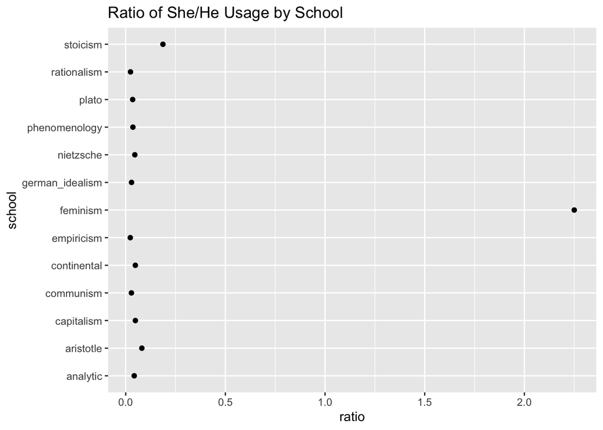

```r
# dot plot of ratio of "she"/"he" usage compared to overall by school
author_school_df %>%
  group_by(school, word) %>%
  summarise(count = sum(count)) %>%
  summarise(ratio_shehe = count[[2]]/count[[1]]) %>%
  ggplot() +
  geom_point(aes(x = ratio_shehe, y = school)) +
  labs(title = "Ratio of She/He Usage by School",
       x = "ratio")
```

```r
# proportional usage of "he"/"she" compared to total "he"/"she" usage by school and time
school_time_df <- heshe_df %>%
  filter(word %in% c("he", "she")) %>%
  group_by(school, original_publication_date, word) %>%
  summarise(count = n()) %>%
  mutate(prop = count / sum(count))
```

Maybe there is progress being made towards a more even split of usage over time for each school. Of note she is used much more frequently over time in feminism. However, there is no clear pattern towards an even split in the other schools over time.

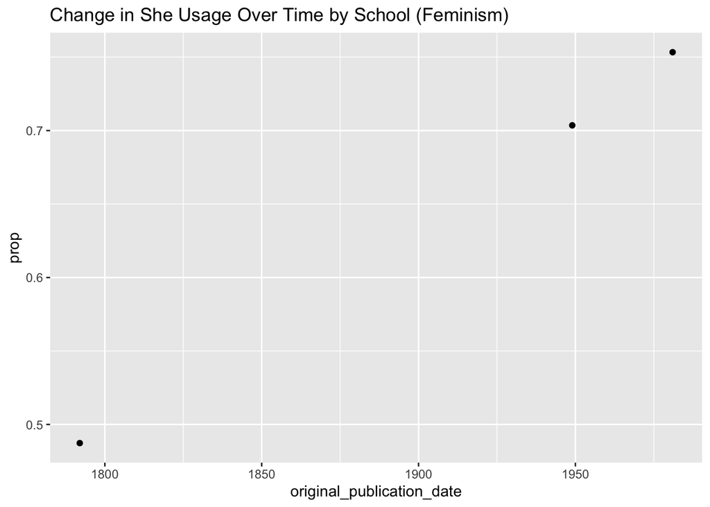

```r
# three separate plots for better resolution
# dotplot of "she" usage by school and time to see change over time for each school
school_time_df %>%
  filter(word == "she", school == "feminism") %>%
  ggplot() +
  geom_point(aes(x = original_publication_date, y = prop)) +
  labs(title = "Change in She Usage Over Time by School (Feminism)")
```

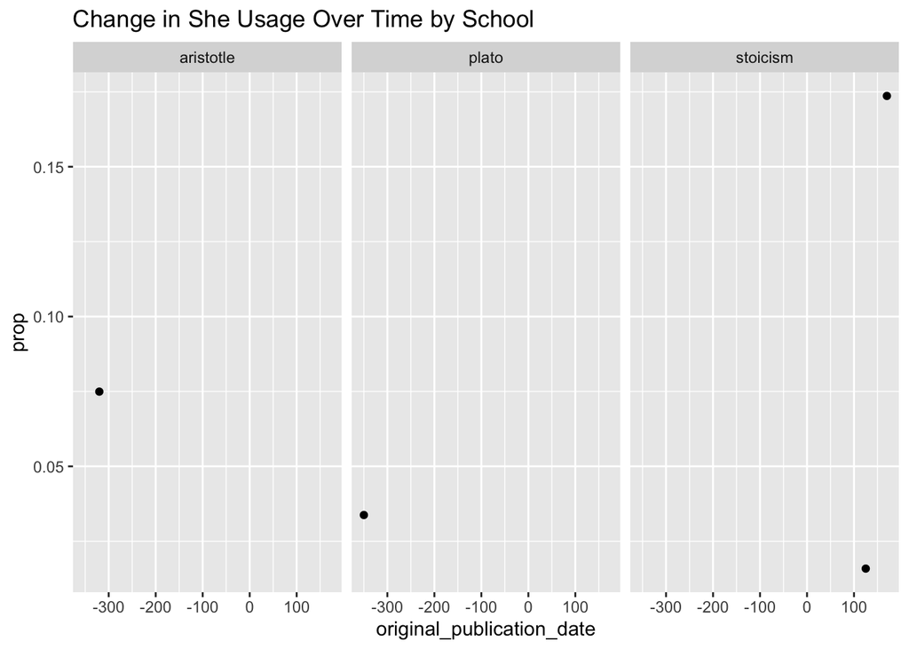

```r
school_time_df %>%
  filter(word == "she", school %in% c("aristotle", "plato", "stoicism")) %>%
  ggplot() +
  geom_point(aes(x = original_publication_date, y = prop)) +
  facet_wrap(~school) +
  labs(title = "Change in She Usage Over Time by School")
```

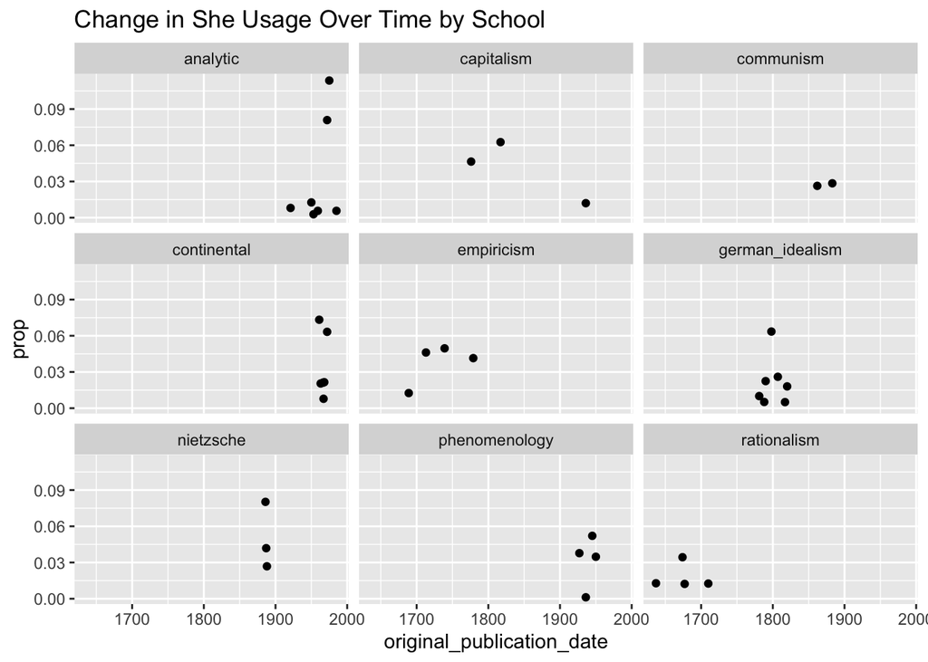

```r
school_time_df %>%
  filter(word == "she", school != "aristotle", school != "plato",
         school != "stoicism", school != "feminism") %>%
  ggplot() +
  geom_point(aes(x = original_publication_date, y = prop)) +
  facet_wrap(~school) +
  labs(title = "Change in She Usage Over Time by School")
```

Ultimately, we conclude that yes there is a gender bias towards male associated pronouns throughout the history of philosophy.